# Bob Ross and His Son’s Inspirations

Anthony Arroyo

9/07/2022

# Datasets

```r
repo = "https://github.com/fivethirtyeight/data/tree/master/bob-ross"
article = "https://blog.twoinchbrush.com/article/what-happened-to-steve-ross-the-son-of-bob-ross/"
link = "https://raw.githubusercontent.com/fivethirtyeight/data/master/bob-ross/elements-by-episode.csv"

bobRoss = if (file.exists(basename(link))) {
  read.csv(basename(link))
} else {
  read.csv(link)
}
```

# Overview

Through a meticulous effort, we have a collection of qualifiers regarding the contents of Bob Ross’ paintings. From seasons 1 through 31, we have an idea of how many lakes and mountains he has painted on television. Bob Ross was inspired from his stay in Alaska and his son Steve Ross perhaps inspired by Bob himself. An avenue of interest lies in looking for divergence from these two artists and seeing what we learn.

```r
### Filters data frame for columns that are specifically integer vectors
FilterInt <- function(df) {
  sapply(df, typeof) %>%
    { which(. == "integer") } %>%
      df[, .]
}

### Flattens a data frame and computes a sum on integer columns
SumOccurences <- function(df) {
  FilterInt(df) %>%
    sapply(., sum)
}

### Normalizes a row to a percent value
Percent <- function(x) { x / max(x) }

### Generates the integer inputs for weighting the raw sparse data
ChunkVals <- function(maxVal = 100, size = 10, keepTail = TRUE) {
  if (maxVal[[1]] < 1 || size[[1]] < 0) return(NA)
  len = floor(size[[1]])

  lhs = seq.int(1, maxVal[[1]], len)
  rhs = seq.int(len, length(lhs)*len, len)
  weight = rep(1, length(lhs))

  last_i = length(lhs)
  rhs[last_i] = maxVal[[1]]
  weight[last_i] = (rhs[last_i] - lhs[last_i] + 1) / min(rhs[last_i], len)

  result = data.frame(lhs = lhs, rhs = rhs, weight = weight)

  if (keepTail) {
    return(result)
  } else {
    return(result[-last_i, ])
  }
}

### Congregates sparse data into sizeable chunks, like a dataloader but not randomized
Chunk <- function(df, n_rows = 10, keepTail = TRUE) {
  if (purrr::is_empty(nrow(df)) || nrow(df) < 1)
    return(warning(NA))

  data = FilterInt(df)

  ChunkVals(nrow(df), n_rows, keepTail) %>%
    { mapply(.$lhs, .$rhs, .$weight, FUN = function(a, b, w) {
      floor(SumOccurences(data[a:b, ]) / w)
    })} %>%
      t(.) %>%
        as.data.frame(.) %>%
          dplyr::mutate(indices = n_rows * 1:nrow(.)) %>%
            dplyr::select(indices, dplyr::everything())
}
```

# Initial Impressions

When we tally and summarize the presence of certain features, we can draw some starting ideas. It is self evident that even seeing one episode means you have seen them both draw trees. For another example, Bob Ross only rarely draws barns and similarly, neither does Steve Ross. One strong contrast however, Bob Ross has much more interest drawing natural structures like cabins. Moreover, Steve Ross has a much stronger affinity for clouds than his father.

```r
# Converts the sparse tallies into a percent per column by artist
bobChoices = bobRoss %>%
  dplyr::filter(GUEST == 0) %>%
    SumOccurences(.)
steveChoices = bobRoss %>%
  dplyr::filter(STEVE_ROSS == 1) %>%
    SumOccurences(.)

# Delta (difference) between Bob and Steve
disparity = (Percent(bobChoices) - Percent(steveChoices)) %>%
  { print(head(., 15)) ; . }
```

```
##     APPLE_FRAME AURORA_BOREALIS            BARN           BEACH            BOAT
##     0.002898551     0.005797101     0.049275362     0.078260870     0.005797101
##          BRIDGE        BUILDING          BUSHES           CABIN          CACTUS
##     0.020289855     0.002898551     0.063504611     0.197101449     0.011594203
##    CIRCLE_FRAME          CIRRUS           CLIFF          CLOUDS         CONIFER
##     0.002898551    -0.200263505     0.023188406    -0.334123847    -0.144664032
```

# Visualizing our findings

In order to make the nuances a bit more evident, let’s graph it. By taking out the common themes, we notice that Bob Ross really likes to paint structures, paths, rivers, grass, and cabins. However, there’s a second takeaway from this idea since this graph represents *disparity* between the two artists. Since there is a lack of human constructions, Steve Ross’ work amplifies the presence of mountains, lakes, clouds, and so on.

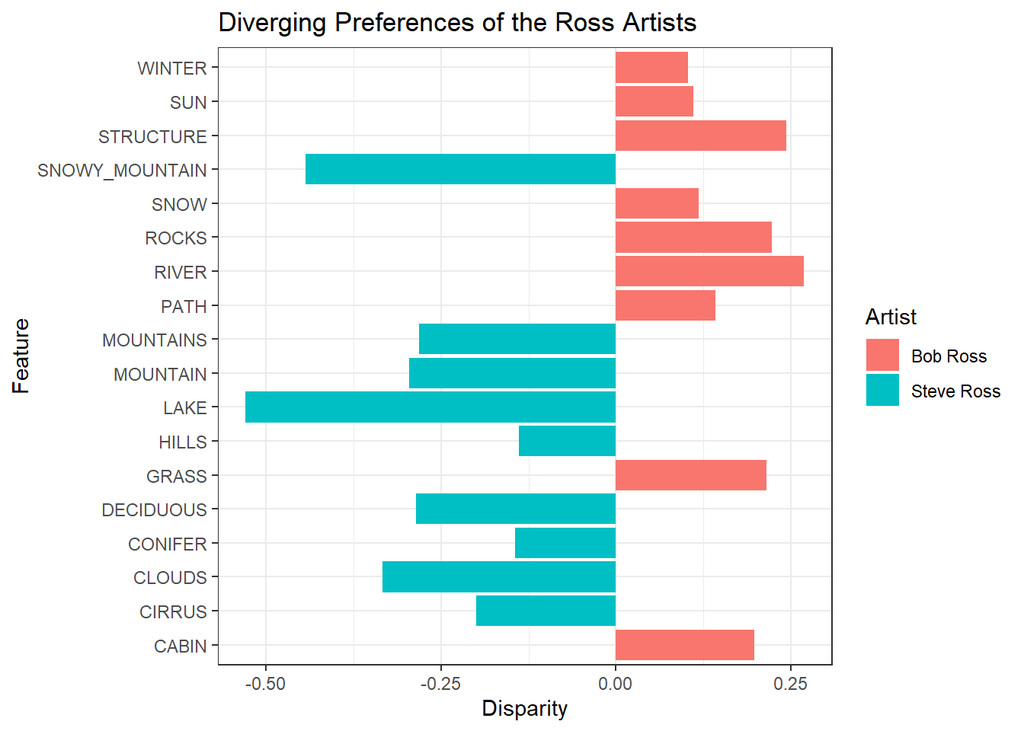

```r
### Graphs the divergence delta by filtering weak correlations and highlighting values
reshape2::melt(disparity, value.name = "Disparity") %>%
  dplyr::mutate(Feature = rownames(.)) %>%
    dplyr::mutate(who = as.numeric(disparity > 0)) %>%
      dplyr::mutate(Artist = ifelse(who, "Bob Ross", "Steve Ross")) %>%
        .[-which(.$Feature %in% c("GUEST", "STEVE_ROSS")), ] %>%
          .[which(.$Disparity > 0.1 | .$Disparity < -0.1), ] %>%
            ggplot2::ggplot(.) +
            ggplot2::aes(y = Feature, x = Disparity, fill = Artist) +
            ggplot2::geom_bar(stat = "identity") +
            ggplot2::ggtitle("Diverging Preferences of the Ross Artists") +
            ggplot2::theme_bw()
```

# Suggestions

Let’s reiterate that Bob Ross likes structures, paths, rivers, grass, and cabins whereas Steve Ross does not. All of these are hallmarks and indicators of civilization. It appears that Steve Ross makes an either conscious or unconscious effort to avoid depicting humanity. Alternatively then, perhaps Bob Ross is more comfortable blending into society? It would also be reflective of the high success of the show, which is largely from his calm personality. Either way, it does suggest a tinge of loneliness in Steve Ross’ life. I would be curious to know if Steve Ross would be considered as sociable or amicable among his peers as his father.